# 20251125 4 species re-entry into SC from Pi limited media

Bin He

2026-02-16, updated 2026-02-25

```r
require(tidyverse)
library(gcplyr)
require(cowplot)
```

```r
# Set ggplot theme
old = theme_set(theme_bw(base_size = 14))
```

## Goal

In an earlier experiment, Emily observed that *S. cerevisiae* accumulates a much larger amount of polyphosphate (polyP) when grown to the saturation phase in rich media. Then, when the cells are phosphate (Pi) limited, they quickly mobilize the stored polyP within 2h. Based on this, we hypothesize that *S. cerevisiae* quickly mobilizes the polyP storage upon Pi limitation in order to temporarily restore Pi homeostasis inside the cell. This in turn downregulates the general stress response while letting the cells return to close-to-normal growth states. The prediction is, at the time points where polyP experiences a sharp decrease but before it is all gone, the cells should be at a faster growth rate than the time points either before polyP is mobilized (very early in Pi limitation) or when the polyP is completely mobilized. To test this, we will take samples of the culture at different time points during Pi starvation corresponding to the various levels of polyP we measured, and then re-inoculate them into rich media to see how well they grow.

## Data

Two batches of data were collected on two different days, each containing two species.

### Load example data from `gcplyr`

This helps us to see whether the functions we wrote work properly by checking them against the example dataset and the expected results based on the package author’s [vignettes](https://mikeblazanin.github.io/gcplyr/articles/analyze.html#lag)

```r
# This code was previously explained
# Here we're re-running it so it's available for us to work with
example_tidydata <- trans_wide_to_tidy(example_widedata_noiseless,
                                       id_cols = "Time")
example_design <- make_design(
  pattern_split = ",", nrows = 8, ncols = 12,
  "Bacteria_strain" = make_designpattern(
    values = paste("Strain", 1:48),
    rows = 1:8, cols = 1:6, pattern = 1:48, byrow = TRUE),
  "Bacteria_strain" = make_designpattern(
    values = paste("Strain", 1:48),
    rows = 1:8, cols = 7:12, pattern = 1:48, byrow = TRUE),
  "Phage" = make_designpattern(
    values = c("No Phage"), rows = 1:8, cols = 1:6, pattern = "1"),
  "Phage" = make_designpattern(
    values = c("Phage Added"), rows = 1:8, cols = 7:12, pattern = "1"))
ex_dat_mrg <- merge_dfs(example_tidydata, example_design)
ex_dat_mrg$Well <-
  factor(ex_dat_mrg$Well,
         levels = paste(rep(LETTERS[1:8], each = 12), 1:12, sep = ""))
ex_dat_mrg$Time <- ex_dat_mrg$Time/3600 #Convert time to hours
ex_dat_mrg <-
  mutate(group_by(ex_dat_mrg, Well, Bacteria_strain, Phage),
         deriv = calc_deriv(x = Time, y = Measurements),
         percap_deriv = calc_deriv(x = Time, y = Measurements,
                                        percapita = TRUE, blank = 0,
                                        window_width_n = 5, trans_y = "log"),
         doub_time = doubling_time(y = percap_deriv))
sample_wells <- c("A1", "F1", "F10", "E11")
# Drop unneeded columns (optional, but makes things cleaner)
ex_dat_mrg <- dplyr::select(ex_dat_mrg,
                            Time, Well, Measurements, Bacteria_strain, Phage,
                            deriv, percap_deriv)

# calculate lag time etc.
ex_dat_mrg_sum <-
  summarize(group_by(ex_dat_mrg, Bacteria_strain, Phage, Well),
            lag_time = lag_time(y = Measurements, x = Time,
                                deriv = percap_deriv, blank = 0),
            max_percap = max_gc(percap_deriv),
            max_percap_time = Time[which_max_gc(percap_deriv)],
            max_percap_dens = Measurements[which_max_gc(percap_deriv)],
            min_dens = min_gc(Measurements))
```

### Import growth curve data

Experiment on 2025-11-25 and 11-26 Helper function

```r
well_levels <- paste0(rep(LETTERS[1:8], each = 12), 1:12)
threshold_empty <- 0.12 # this is the threshold we use to identify empty wells,
                        # based on the distribution of max OD values across wells
# this is the column we use as blank wells for background subtraction,
# since it is in between the two sets of samples. We can change this if needed.
blank_wells <- paste0(LETTERS[1:8], '6')

my_read_plate <- function(dat_file, sample_file, blank_wells){
  # using the read_wides() function from gcplyr to read in the data
  dat_wide <- read_wides(files = dat_file) |>
    # convert time into proper formats
    mutate(Time = time_length(hms(Time), unit = "hour"))
  dat_tidy <- trans_wide_to_tidy(wides = dat_wide, id_cols = c("file", "Time")) |>
    #Set up the Well column so they plot in the correct order
    mutate(Well = factor(Well, levels = well_levels))
  # import meta information
  sample_info <- read_csv(sample_file)
  # identify empty wells
  empty_wells <- dat_tidy %>%
    group_by(Well) %>%
    summarize(Max = max(Measurements, na.rm = TRUE)) %>%
    filter(Max < threshold_empty) %>%
    pull(Well)
  # remove background, using user-provided blank_wells. if not provided,
  # use the empty_wells as the blank wells
  if(missing(blank_wells)){
    blank_wells <- empty_wells
  }
  blank_value <- dat_tidy %>%
    filter(Well %in% blank_wells) %>%
    summarize(blank_value = mean(Measurements, na.rm = TRUE)) %>%
    pull(blank_value)
  # remove background
  dat_processed <- dat_tidy |>
    mutate(
      # and subtract it from all measurements in that plate
      Measurements = Measurements - blank_value
    ) |>
    filter(!Well %in% empty_wells)
  return(list(d_input = dat_tidy, d_processed = dat_processed,
              blank_wells = blank_wells, blank_value = blank_value,
              empty_wells = empty_wells, sample_info = sample_info))
}
```

```r
# Sc and Cg
dat_p1 <- my_read_plate(dat_file = "../input/20251125_Sc_Cg_reentry.csv",
                        sample_file = "../input/20251125_plate_layout_Sc_Cg.csv",
                        blank_wells)
```

[output not shown]

```r
dat_tidy|>head()
```

|  | file | Time | Well | Measurements |
| --- | --- | --- | --- | --- |
| 1 | ../input/20251125_Sc_Cg_reentry | 0.1527778 | A1 | 0.082 |
| 2 | ../input/20251125_Sc_Cg_reentry | 0.1527778 | A2 | 0.086 |
| 3 | ../input/20251125_Sc_Cg_reentry | 0.1527778 | A3 | 0.082 |
| 4 | ../input/20251125_Sc_Cg_reentry | 0.1527778 | A4 | 0.084 |
| 5 | ../input/20251125_Sc_Cg_reentry | 0.1527778 | A5 | 0.081 |
| 6 | ../input/20251125_Sc_Cg_reentry | 0.1527778 | A6 | 0.081 |

```r
dat_wide |> head()
```

|  | file | Time | A1 | A2 | A3 | A4 | A5 | A6 | A7 | A8 | A9 | A10 | A11 | A12 | B1 | B2 | B3 | B4 | B5 | B6 | B7 | B8 | B9 | B10 | B11 | B12 | C1 | C2 | C3 | … |
| --- | --- | --- | --- | --- | --- | --- | --- | --- | --- | --- | --- | --- | --- | --- | --- | --- | --- | --- | --- | --- | --- | --- | --- | --- | --- | --- | --- | --- | --- | --- |
| 2 | ../input/20251125_Sc_Cg_reentry | 0.1527778 | 0.082 | 0.086 | 0.082 | 0.084 | 0.081 | 0.081 | 0.082 | 0.105 | 0.102 | 0.081 | 0.082 | 0.083 | 0.081 | 0.1 | 0.1 | 0.129 | 0.099 | 0.084 | 0.102 | 0.117 | 0.103 | 0.478 | 0.083 | 0.082 | 0.081 | 0.101 | 0.104 | … |
| 3 | ../input/20251125_Sc_Cg_reentry | 0.3194444 | 0.082 | 0.086 | 0.082 | 0.084 | 0.081 | 0.082 | 0.082 | 0.106 | 0.102 | 0.082 | 0.082 | 0.083 | 0.081 | 0.096 | 0.101 | 0.13 | 0.099 | 0.084 | 0.104 | 0.118 | 0.104 | 0.449 | 0.084 | 0.082 | 0.081 | 0.103 | 0.105 | … |
| 4 | ../input/20251125_Sc_Cg_reentry | 0.4861111 | 0.082 | 0.086 | 0.082 | 0.084 | 0.081 | 0.082 | 0.082 | 0.107 | 0.106 | 0.082 | 0.082 | 0.083 | 0.081 | 0.096 | 0.102 | 0.131 | 0.1 | 0.085 | 0.105 | 0.119 | 0.108 | 0.385 | 0.084 | 0.082 | 0.081 | 0.105 | 0.105 | … |
| 5 | ../input/20251125_Sc_Cg_reentry | 0.6527778 | 0.082 | 0.086 | 0.082 | 0.084 | 0.081 | 0.081 | 0.082 | 0.108 | 0.103 | 0.082 | 0.082 | 0.083 | 0.081 | 0.096 | 0.103 | 0.132 | 0.101 | 0.084 | 0.105 | 0.12 | 0.107 | 0.364 | 0.084 | 0.082 | 0.081 | 0.103 | 0.106 | … |
| 6 | ../input/20251125_Sc_Cg_reentry | 0.8194444 | 0.082 | 0.086 | 0.082 | 0.084 | 0.081 | 0.082 | 0.082 | 0.108 | 0.104 | 0.082 | 0.082 | 0.083 | 0.081 | 0.097 | 0.104 | 0.133 | 0.101 | 0.085 | 0.106 | 0.121 | 0.108 | 0.359 | 0.084 | 0.082 | 0.081 | 0.103 | 0.107 | … |
| 7 | ../input/20251125_Sc_Cg_reentry | 0.9861111 | 0.082 | 0.086 | 0.082 | 0.084 | 0.081 | 0.082 | 0.082 | 0.108 | 0.108 | 0.082 | 0.082 | 0.083 | 0.081 | 0.098 | 0.106 | 0.136 | 0.103 | 0.085 | 0.108 | 0.125 | 0.11 | 0.355 | 0.084 | 0.082 | 0.081 | 0.104 | 0.109 | … |

```r
dat_wide
```

[output not shown]

[output cut: 99 more lines]

```r
print(10)
```

```
[1] 10
```

```r
dim(dat_wide)
```

```
[1] 109  98
```

```r
print(dat_wide)
```

[output not shown]

[output cut: 99 more lines]

```r
dat_wide[1,2]
```

```
[1] 0.1527778
```

```r
dim(dat_tidy)
```

```
[1] 10464     4
```

```r
head(dat_tidy)
```

|  | file | Time | Well | Measurements |
| --- | --- | --- | --- | --- |
| 1 | ../input/20251125_Sc_Cg_reentry | 0.1527778 | A1 | 0.082 |
| 2 | ../input/20251125_Sc_Cg_reentry | 0.1527778 | A2 | 0.086 |
| 3 | ../input/20251125_Sc_Cg_reentry | 0.1527778 | A3 | 0.082 |
| 4 | ../input/20251125_Sc_Cg_reentry | 0.1527778 | A4 | 0.084 |
| 5 | ../input/20251125_Sc_Cg_reentry | 0.1527778 | A5 | 0.081 |
| 6 | ../input/20251125_Sc_Cg_reentry | 0.1527778 | A6 | 0.081 |

```r
dat_tidy[1,]
```

|  | file | Time | Well | Measurements |
| --- | --- | --- | --- | --- |
| 1 | ../input/20251125_Sc_Cg_reentry | 0.1527778 | A1 | 0.082 |

```r
dat_tidy[1:2,]
```

|  | file | Time | Well | Measurements |
| --- | --- | --- | --- | --- |
| 1 | ../input/20251125_Sc_Cg_reentry | 0.1527778 | A1 | 0.082 |
| 2 | ../input/20251125_Sc_Cg_reentry | 0.1527778 | A2 | 0.086 |

```r
Q
```

### Plot growth curves in plate layout

plot the first plate

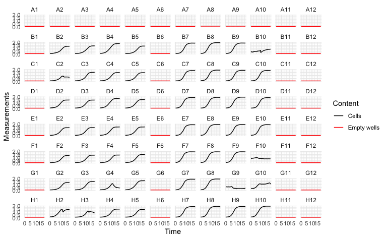

```r
attach(dat_p1)
d_input %>%
  ggplot(aes(x = Time, y = Measurements)) +
  geom_line(aes(color = Well %in% empty_wells)) +
  scale_color_manual("Content", values = c("black", "red"),
                     labels = c("Cells", "Empty wells")) +
  facet_wrap(~Well, nrow = 8, ncol = 12) +
  theme_minimal()
```

plot the second plate

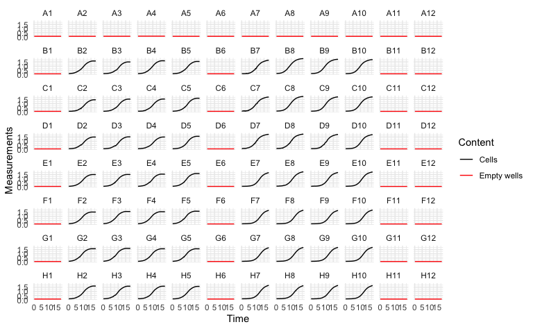

```r
attach(dat_p2)
d_input %>%
  ggplot(aes(x = Time, y = Measurements)) +
  geom_line(aes(color = Well %in% empty_wells)) +
  scale_color_manual("Content", values = c("black", "red"),
                     labels = c("Cells", "Empty wells")) +
  facet_wrap(~Well, nrow = 8, ncol = 12) +
  theme_minimal()
```

```r
detach(dat_p2)
```

## Preprocessing

2. Calculate derivatives

```r
dat_deriv <- dat_bg_rm %>%
  group_by(Well) %>%
  mutate(
    # plain derivative
    deriv = calc_deriv(x = Time, y = Measurements, window_width_n = 5),
    percap_deriv = calc_deriv(x = Time, y = Measurements,
                              percapita = TRUE,
                              blank = 0,
                              window_width_n = 5,
                              trans_y = "log")
  )

dat_merged <- left_join(meta_info, dat_deriv, by = "Well")
```

Plot plain derivative

[output not shown]

Per capita derivative

[output not shown]

### Lag time and other summary stats calculation

```r
dat_sum <- dat_deriv %>%
  group_by(Well) %>%
  summarize(
    min_dens = min_gc(Measurements, na.rm = TRUE),
    max_dens = max_gc(Measurements, na.rm = TRUE),
    time_to_5pc_max = first_above(x = Time, y = Measurements,
                                  threshold = max_dens*0.05, return = "x"),
    lag_time = lag_time(x = Time, y = Measurements,
                        deriv = percap_deriv, blank = 0),
    max_percap = max_gc(percap_deriv),
    max_percap_time = Time[which_max_gc(percap_deriv)],
    max_percap_dens = Measurements[which_max_gc(percap_deriv)],
    min_dens = min_gc(Measurements)
  ) %>%
  full_join(meta_info, by = "Well") %>%
  select(Well, Genotype, Group, everything())
```

### Diagnostic plot

Build a diagnostic plot function

```r
my_diag_plot <- function(df, df.sum, well){
  # df is the data frame containing the data
  # df.sum contains the per well estimates calculated from the raw data
  # this function is aimed at one well of data, specified by "well"
  # check to see if the well number is valid
  if(!well %in% df$Well){
    stop(paste(well, "is not a valid well", sep = " "))
  }

  # subset the df
  dat <- filter(df, Well == well)
  # extract the estimates
  par <- filter(df.sum, Well == well)

  # for overlaying the derivatives on the plot,
  # we will calculate a scaling factor
  tmp <- dat %>% summarize(
    min_OD = min_gc(Measurements), max_OD = max_gc(Measurements),
    min_deriv = min_gc(deriv), max_deriv = max_gc(deriv),
    rng_OD = max_OD - min_OD,
    rng_deriv = max_deriv - min_deriv,
    sf_deriv = rng_OD / rng_deriv,
    min_logOD = min_gc(log(Measurements)), max_logOD = max_gc(log(Measurements)),
    min_percap_deriv = min_gc(percap_deriv), max_percap_deriv = max_gc(percap_deriv),
    rng_logOD = max_logOD - min_logOD,
    rng_percap_deriv = max_percap_deriv - min_percap_deriv,
    sf_percap_deriv = rng_logOD / rng_percap_deriv
  )

  # make the linear growth curve plot
  p1 <- dat %>%
    mutate(
      scaled_deriv = (deriv - tmp$min_deriv)*tmp$sf_deriv + tmp$min_OD
    ) %>%
    ggplot(aes(x = Time, y = Measurements)) + geom_point(size = 0.4) +
    geom_line() +
    geom_line(aes(x = Time, y = scaled_deriv), color = "blue", linetype = 2) +
    ylab("OD")

  # make the semi-log plot
  p2 <- dat %>%
    mutate(
      scaled_percap_deriv = (percap_deriv-tmp$min_percap_deriv)*tmp$sf_percap_deriv +
        tmp$min_logOD
    ) %>%
    ggplot(aes(x = Time, y = log(Measurements))) + geom_point() + geom_line() +
    geom_line(aes(x = Time, y = scaled_percap_deriv),
              color = "blue", linetype = 2) +
    geom_abline(
      data = par,
      color = "red",
      aes(slope = max_percap,
          intercept = log(max_percap_dens) - max_percap * max_percap_time)
    ) +
    geom_vline(data = par,
               aes(xintercept = lag_time), lty = 2) +
    geom_hline(data = par,
               aes(yintercept = log(min_dens))) +
    ylab("log OD")
  # draw the derivative and per_capita_derivative

  plot_grid(p1, p2, nrow = 2)
}
```

```r
problem_wells <- c("C10", "D7", "E9", "F8")
tmp <- filter(lag_time, Well %in% problem_wells)

ggplot(data = tmp, aes(x = Time, y = log(Measurements))) +
  geom_point() +
  facet_wrap(~Well) +
  geom_abline(tmp,
              color = "red",
              aes(slope = max_percap,
                  intercept = log(max_percap_dens) - max_percap*max_percap_time)) +
  geom_vline(data = tmp,
             aes(xintercept = lag_time), lty = 2) +
  geom_hline(data = tmp,
             aes(yintercept = log(min_dens)))
```

[output not shown]

#Here I plot lag times of raw data

```r
PPKOdata_sum <- summarize(
  group_by(PPKOdata_merged, Well),
  lag_time = lag_time(x = Time, y = Measurements, deriv = percap_deriv,
                      blank = 0),
  max_percap = max(percap_deriv, na.rm = TRUE),
  max_dens = max(Measurements),
  auc = auc(y = Measurements, x = as.numeric(Time)))
```

```r
PPKOdata_sum$Well <- factor(PPKOdata_sum$Well,
                        levels = paste0(rep(LETTERS[1:8], each = 12), 1:12))

#Plot lag time
ggplot(data = PPKOdata_sum) +
  geom_text(aes(label = round(lag_time, 2), x = 1, y = 1)) +
  facet_wrap(~ Well, ncol = 12) +
  labs(title = "Lag time by well") +
  theme(axis.title = element_blank(),
        axis.text = element_blank(),
        axis.ticks = element_blank())
```

[output not shown]

# Here I am trying to use “smooth” to adjust try to remove noise

```r
PPKOdata_merged <-
  PPKOdata_merged %>%
  group_by(Well) %>%
  mutate(
    meas_smooth = smooth_data(
      x = Time,
      y = Measurements,
      sm_method = "moving-average",
      window_width_n = 5
    )
  ) %>%
  ungroup()
```

```r
PPKOdata_merged <-
  PPKOdata_merged %>%
  group_by(Well) %>%
  mutate(
    percap_deriv_smooth = c(
      NA,
      diff(log(meas_smooth)) / diff(Time)
    )
  ) %>%
  ungroup()
```

```r
PPKOdata_sum_smooth <-
  PPKOdata_merged %>%
  group_by(Well) %>%
  summarize(
    lag_time = lag_time(
      x = Time,
      y = meas_smooth,
      deriv = percap_deriv_smooth,
      blank = 0
    ),
    max_percap = max(percap_deriv_smooth, na.rm = TRUE),
    max_dens = max(meas_smooth, na.rm = TRUE),
    auc = auc(y = meas_smooth, x = as.numeric(Time))
  )
```

```r
ggplot(PPKOdata_sum_smooth) +
  geom_text(aes(label = round(lag_time, 2), x = 1, y = 1)) +
  facet_wrap(~ Well, ncol = 12) +
  labs(title = "Lag time by well (smoothed data)") +
  theme(
    axis.title = element_blank(),
    axis.text = element_blank(),
    axis.ticks = element_blank()
  )
```

[output not shown]

```r
PPKOdata_merged$Well <-
  factor(PPKOdata_merged$Well,
         levels = paste0(rep(LETTERS[1:8], each = 12), 1:12))
ggplot(data = PPKOdata_merged,
       aes(x = Time, y = meas_smooth)) +
  geom_line() +
  facet_wrap(~ Well, nrow = 8, ncol = 12) +
  labs(
    title = "Smoothed growth curves",
    y = "Smoothed measurements"
  )
```

[output not shown]

#After I smooth the data I need to figure out what derivative value to use

```r
PPKOdata_deriv_multi <-
  PPKOdata_merged %>%
  group_by(Well) %>%
  mutate(
    derivpercap_3 = calc_deriv(
      x = Time, y = meas_smooth,
      percapita = TRUE, blank = 0,
      window_width_n = 3
    ),
    derivpercap_5 = calc_deriv(
      x = Time, y = meas_smooth,
      percapita = TRUE, blank = 0,
      window_width_n = 5
    ),
    derivpercap_9 = calc_deriv(
      x = Time, y = meas_smooth,
      percapita = TRUE, blank = 0,
      window_width_n = 9
    )
  ) %>%
  ungroup()
```